# Pathway analysis

Asela Wijeratne

```
During this session you will learn about:

1. Use of GAGE package to do pathway analysis

   a. "Native workflow"

   b. Combined workflow with RNAseq

2. Interpret the GAGE output

3. Use of Pathview to visualize the perturbed KEGG pathways



For more details, please go to relevent reference manauls:
GAGE package and tutorial:

http://bioconductor.org/packages/devel/bioc/html/gage.html

pathview and gageData:

http://bioconductor.org/packages/devel/bioc/html/pathview.html

http://bioconductor.org/packages/devel/data/experiment/html/gageData.html
EdgeR user guide:

http://bioconductor.org/packages/release/bioc/vignettes/edgeR/inst/doc/edgeRUsersGuide.pdf
```

## Installing necessary packages

### Before you start the tutorial following packages needs to be installed.

### Install required packages:

```
BiocManager::install(c("pathview", "edgeR", "gage"))
```

## Load required packages

```r
library(edgeR)
library(gage)
library(pathview)
```

## Getting and preprocessing data

[output not shown]

```r
rnaseq_URL <- "https://github.com/vsbuffalo/rna-seq-example/raw/master/results/raw-counts.txt"
download.file(rnaseq_URL, destfile = "rnaseq_data.txt")
```

````
If above code work, ignore the rest of the next part of the code.

You can also get the data from the following link and save it in the Desktop/pathway_analysis``` folder.

http://bit.ly/150826_rnaseqdata
````

## Read the data into R using the following code:

```r
##you can use your own count data here:

rnaseq_data <- read.table("rnaseq_data.txt", header=TRUE)
```

## Let’s look at the head of the data set.

```r
head(rnaseq_data)
```

```
##           SRR070570 SRR070571 SRR070572 SRR070573
## AT1G01010         5        13        15        15
## AT1G01020       182       177       121       144
## AT1G01030        16        11         9        10
## AT1G01040        30        32       113       132
## AT1G01046         0         1         0         2
## AT1G01050        87        82       114       107
```

## This is how they are labelled:

```
GEO:GSM613465: wild type samples
        SRR070570: replicate 1
        SRR070571: replicate 2
GEO:GSM613466: hy5 mutant samples
        SRR070572: replicate 1
        SRR070573: replicate 2
```

## Rename the columns so we can identify them easily.

```r
colnames(rnaseq_data) <- c("WT_1", "WT_2", "hy_1", "hy_2")
```

## Getting KEGG data

### Finding your species in KEGG

````
First, we need to make sure the species we work with is found in KEGG database. You can go the following webpage and see the organism is list:

http://rest.kegg.jp/list/organism


In addition, ```pathview``` also carry a data matrix with KEGG supported species.  You can explore this matrix as well.
````

```r
data(korg)
head(korg)
```

```
##      ktax.id  tax.id  kegg.code scientific.name
## [1,] "T01001" "9606"  "hsa"     "Homo sapiens"
## [2,] "T01005" "9598"  "ptr"     "Pan troglodytes"
## [3,] "T02283" "9597"  "pps"     "Pan paniscus"
## [4,] "T02442" "9595"  "ggo"     "Gorilla gorilla gorilla"
## [5,] "T01416" "9601"  "pon"     "Pongo abelii"
## [6,] "T03265" "61853" "nle"     "Nomascus leucogenys"
##      common.name                     entrez.gnodes kegg.geneid ncbi.geneid
## [1,] "human"                         "1"           "270"       "270"
## [2,] "chimpanzee"                    "1"           "457329"    "457329"
## [3,] "bonobo"                        "1"           "100984343" "100984343"
## [4,] "western lowland gorilla"       "1"           "101131425" "101131425"
## [5,] "Sumatran orangutan"            "1"           "100445431" "100445431"
## [6,] "northern white-cheeked gibbon" "1"           "100586984" "100586984"
##      ncbi.proteinid uniprot
## [1,] "NP_000027"    "P23109"
## [2,] "XP_016783033" "H2Q039"
## [3,] "XP_003822069" "A0A2R9CI03"
## [4,] "XP_004054355" "G3QRV7"
## [5,] "XP_024103376" "Q5R9Z0"
## [6,] "XP_030665586" "G1S766"
```

### You can get the short names for Arabidopsis by searching the `korg` data.

```r
## need to change this for your data

org <- "arabidopsis thaliana"
species <- unlist(sapply(1:ncol(korg), function(i) {
    agrep(org, korg[, i])
}))
korg[species, 1, drop = F]
```

```
##      ktax.id
## [1,] "T00041"
```

## Creating the KEGG dataset for GAGE analysis

`kegg.gsets` can be used to get KEGG data for any species present in the KEGG database. GAGE manual recommends that you save this data as a .Rdata file. This way you don’t need to download this each time you need to use and also increase the reproducibility.

```r
##you can use your organism code here
kegg_arab <- kegg.gsets("ath")
kegg.gs <- kegg_arab$kg.sets[kegg_arab$sigmet.idx]
```

## GAGE “native” workflow

### 1. Remove zero counts in all samples.

```r
rnaseq_counts <- rnaseq_data # rename the dataset

dim(rnaseq_counts)
```

```
## [1] 33602     4
```

```r
non_zero <- rowSums(rnaseq_counts) != 0
rnaseq_counts <- rnaseq_counts[non_zero,]
# number of genes left after removing zero counts

dim(rnaseq_counts)
```

```
## [1] 29954     4
```

### 2. Normalize library sizes

```r
libsizes <- colSums(rnaseq_counts)
size_factor <- libsizes / exp(mean(log(libsizes)))
norm_counts <- t(t(rnaseq_counts) / size_factor)
range(norm_counts)
```

```
## [1]       0 1657444
```

### 3. Variance stabilizing transformation

````
We need to add small (positive) value to avoid getting ```-inf``` during log transformation. We will add 8 as per GAGE manual.
````

```r
norm_counts <- log2(norm_counts + 8)
range(norm_counts)
```

```
## [1]  3.00000 20.66054
```

```r
head(norm_counts)
```

```
##               WT_1     WT_2     hy_1     hy_2
## AT1G01010 3.721186 4.436767 4.450872 4.516097
## AT1G01020 7.620982 7.599515 6.905490 7.237072
## AT1G01030 4.620736 4.289539 4.028738 4.163569
## AT1G01040 5.290195 5.379117 6.813605 7.118479
## AT1G01046 3.000000 3.178005 3.000000 3.319643
## AT1G01050 6.618772 6.556808 6.825416 6.834829
```

```r
write.csv(x = norm_counts, file = "norm_counts.csv")
```

```
You can do MA and PCA plots to see the processed data variances and overall variances and similarity between samples, respectively.
```

### 4. Define reference and experiment samples

```r
ref_idx <- 1:2 #wt
samp_idx <- 3:4 #hy mutant
```

### 5. Enrichment analysis

`` Here we are going to perform the enrichment analysis using fold change (default) as the gene set statistics. In addition, control (wt) and experiment (hy) are not paired. Therefore, we going to use `compare ="unpaired"`.

[output not shown]

### 6. Some outputs

First four pathways that are up-regulated.

```r
head(native_kegg_fc$greater[,1:5], 4)
```

```
##                                              p.geomean stat.mean        p.val
## ath00970 Aminoacyl-tRNA biosynthesis       0.001883270  2.956664 2.254469e-05
## ath03008 Ribosome biogenesis in eukaryotes 0.005060033  2.585407 1.486930e-04
## ath03030 DNA replication                   0.007037514  2.498918 2.628296e-04
## ath03420 Nucleotide excision repair        0.014103132  2.193398 1.095541e-03
##                                                  q.val set.size
## ath00970 Aminoacyl-tRNA biosynthesis       0.002637729       56
## ath03008 Ribosome biogenesis in eukaryotes 0.008698542       93
## ath03030 DNA replication                   0.010250354       48
## ath03420 Nucleotide excision repair        0.032044587       64
```

### 7. Meaning of the output:

````
```p.geomean``` geometric mean of the individual p-values from multiple single array based gene set tests.

```stat.mean```  mean of the individual statistics from multiple single array based gene set tests.

```p.val``` gloal p-value or summary of the individual p-values from multiple single array based gene set tests. This is the default p-value being used.

```q.val``` FDR q-value adjustment of the global p-value using the Benjamini & Hochberg procedure implemented in multitest package. This is the default q-value being used.

```set.size```  the effective gene set size, i.e. the number of genes included in the gene set test
````

First four pathways that are down-regulated .

```r
head(native_kegg_fc$less[,1:5], 4)
```

```
##                                               p.geomean  stat.mean        p.val
## ath03010 Ribosome                          2.772218e-36 -13.365677 1.997964e-70
## ath00190 Oxidative phosphorylation         2.368767e-09  -6.064105 6.123044e-17
## ath00195 Photosynthesis                    1.356589e-05  -4.443042 1.482057e-09
## ath00196 Photosynthesis - antenna proteins 2.021442e-05  -4.589787 3.235970e-09
##                                                   q.val set.size
## ath03010 Ribosome                          2.337618e-68      324
## ath00190 Oxidative phosphorylation         3.581981e-15      134
## ath00195 Photosynthesis                    5.780023e-08       45
## ath00196 Photosynthesis - antenna proteins 9.465211e-08       22
```

We can also do significance test to find the pathways that are up-regulated and down-regulated using a given cutoff (default is 0.1). `sigGeneSet` function will also create a heat map, showing the average fold change of expression in pathways that are perturbed.

```r
wt_hy_sig_kegg <-sigGeneSet(native_kegg_fc, outname="wt_hy.kegg")
```

```
## [1] "there are 9 signficantly up-regulated gene sets"
## [1] "there are 15 signficantly down-regulated gene sets"
```

Write the significant pathway sets to a text file.

```r
write.table(rbind(wt_hy_sig_kegg$greater,
                  wt_hy_sig_kegg$less),
            file = "wt_hy_sig_kegg.txt", sep = "\t")
```

## Combine GAGE and EdgeR analysis

First, we will do a differential gene expression analysis using the `edgeR` package.

### 1. Make the study design as follows:

```r
targets <-
        data.frame(sample_name=colnames(rnaseq_data),Group=rep(c("WT","hy"),each=2))

targets
```

```
##   sample_name Group
## 1        WT_1    WT
## 2        WT_2    WT
## 3        hy_1    hy
## 4        hy_2    hy
```

### 2. Create DGElist object.

This is a R list object that can be easily manipulated.

```r
d <- DGEList(counts=rnaseq_data,
             group=targets$Group) # Constructs DGEList object
```

### 3. Remove lowly expressed genes

Keep genes with more than 10 counts per million (calculated with `cpm()`) at least in two samples.

```r
#before filtering:
dim(d)
```

```
## [1] 33602     4
```

```r
keep <- rowSums(cpm(d)> 10) >= 2
d <- d[keep,]
#after filtering:
dim(d)
```

```
## [1] 3902    4
```

### 4. Normalize the data

```r
d$samples$lib.size <- colSums(d$counts)
d <- calcNormFactors(d)
d
```

```
## An object of class "DGEList"
## $counts
##           WT_1 WT_2 hy_1 hy_2
## AT1G01020  182  177  121  144
## AT1G01060  157  194  188  226
## AT1G01080  132  118  113  121
## AT1G01090  597  554  394  436
## AT1G01100  946 1034  457  513
## 3897 more rows ...
##
## $samples
##      group lib.size norm.factors
## WT_1    WT 11236351    1.1770744
## WT_2    WT 11114238    1.1355527
## hy_1    hy 12626487    0.8232849
## hy_2    hy 11707905    0.9087379
```

### 5. multidimentioanl scaling plot

Quick sanity check to see how samples are related to each other using multidimensional scaling plot (MSD).

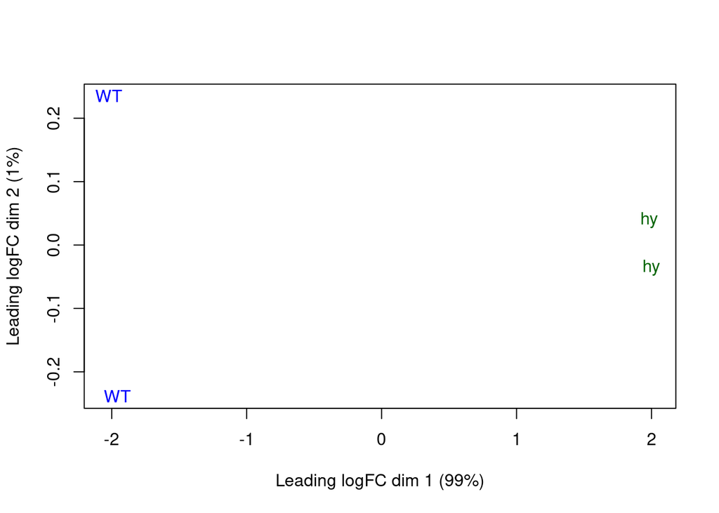

```r
plotMDS(d, labels = targets$Group,
        col = c("darkgreen","blue")[factor(targets$Group)])
```

###6. Estimate the dispersion

```r
d1 <- estimateCommonDisp(d, verbose=T)
```

```
## Disp = 0.00136 , BCV = 0.0369
```

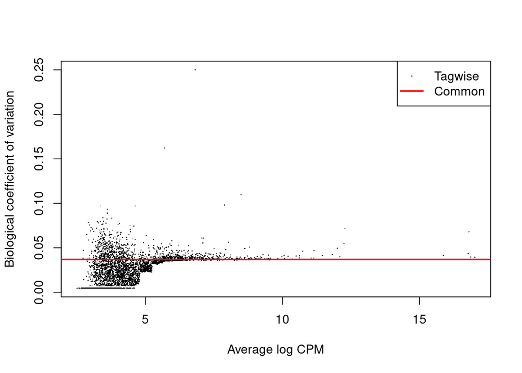

```r
d1 <- estimateTagwiseDisp(d1)

plotBCV(d1)
```

### 7. Differentail gene expression

```r
de.com <- exactTest(d1, pair = c("WT", "hy"))
topTags(de.com, n = 5)
```

```
## Comparison of groups:  hy-WT
##              logFC   logCPM PValue FDR
## AT5G28923 12.67311 5.028388      0   0
## AT4G03910 11.04858 5.627812      0   0
## AT5G45082 10.98975 5.567576      0   0
## AT3G32677 10.37786 4.942707      0   0
## AT3G30663 10.07557 4.635408      0   0
```

```r
FDR <- p.adjust(de.com$table$PValue, method="BH")
de1 <- decideTestsDGE(de.com, adjust.method="BH", p.value=0.05)
summary(de1)
```

```
##        hy-WT
## Down    1491
## NotSig   869
## Up      1542
```

### 8. Making the data suitable for pathway analysis

```r
isDE <- as.logical(de1) # covert to DE set to true/false set

DEnames <- rownames(d)[isDE] # get the DE gene names
edger.fc <- de.com$table$logFC # get the log fold change
names(edger.fc) <- rownames(de.com$table) # assign row names to fold change
exp.fc <- edger.fc
head(exp.fc)
```

```
##  AT1G01020  AT1G01060  AT1G01080  AT1G01090  AT1G01100  AT1G01120
## -0.1407361  0.5328858  0.2015967 -0.1744616 -0.7340612 -0.9657966
```

### 9. Getting DE gene set and fold change

```r
DE_foldchange <- edger.fc[DEnames]

length(DE_foldchange)
```

```
## [1] 3033
```

### 9. Combine with GAGE analysis

```r
fc.kegg.p <- gage(exp.fc, gsets = kegg.gs, ref = NULL, samp = NULL)


head(fc.kegg.p$greater[,1:5], 4)
```

```
##                                        p.geomean stat.mean     p.val    q.val
## ath00970 Aminoacyl-tRNA biosynthesis   0.1280693 1.1644392 0.1280693 0.967014
## ath00500 Starch and sucrose metabolism 0.1446268 1.0706405 0.1446268 0.967014
## ath03040 Spliceosome                   0.2357261 0.7234065 0.2357261 0.967014
## ath03018 RNA degradation               0.3311729 0.4422929 0.3311729 0.967014
##                                        set.size
## ath00970 Aminoacyl-tRNA biosynthesis         20
## ath00500 Starch and sucrose metabolism       37
## ath03040 Spliceosome                         56
## ath03018 RNA degradation                     18
```

### 10. Significance test

```r
wt_hy_sig_kegg <-sigGeneSet(fc.kegg.p, outname="wt_hy.kegg")
```

```
## [1] "No heatmap produced for up-regulated gene sets, only 1 or none signficant."
## [1] "gs.data needs to be a matrix-like object!"
## [1] "gs.data needs to be a matrix-like object!"
## [1] "there are 0 signficantly up-regulated gene sets"
## [1] "there are 2 signficantly down-regulated gene sets"
```

## Visualize the data using Pathview

```r
log_fc= norm_counts[, samp_idx]-rowMeans(norm_counts[, ref_idx])
```

### 1. Selecting the path ids for the upregulated set.

```r
greater_set <- native_kegg_fc$greater[, "q.val"] < 0.1 &
        !is.na(native_kegg_fc$greater[, "q.val"])
greater_ids <- rownames(native_kegg_fc$greater)[greater_set]
head(greater_ids)
```

```
## [1] "ath00970 Aminoacyl-tRNA biosynthesis"
## [2] "ath03008 Ribosome biogenesis in eukaryotes"
## [3] "ath03030 DNA replication"
## [4] "ath03420 Nucleotide excision repair"
## [5] "ath00511 Other glycan degradation"
## [6] "ath03440 Homologous recombination"
```

### 2. Selecting path ids for down-regulated set

```r
less_set <- native_kegg_fc$less[, "q.val"] < 0.1 &
        !is.na(native_kegg_fc$less[,"q.val"])

less_ids <- rownames(native_kegg_fc$less)[less_set]
```

### 3. Combine up and down-regulated path ids.

```r
combine_ids <- substr(c(greater_ids, less_ids), 1, 8)

head(combine_ids)
```

```
## [1] "ath00970" "ath03008" "ath03030" "ath03420" "ath00511" "ath03440"
```

### 4. Visualization

Here we are going to get the first three pathways and visualize using `pathview`.

```r
pv.out.list <- sapply(combine_ids[1:3], function(pid) pathview(
        gene.data =  exp.fc, pathway.id = pid,
        species = "ath", out.suffix="Wt_hy",
        gene.idtype="KEGG"))
```

```
## Info: Downloading xml files for ath00970, 1/1 pathways..
```

```
## Info: Downloading png files for ath00970, 1/1 pathways..
```

```
## Info: Working in directory /cloud/project
```

```
## Info: Writing image file ath00970.Wt_hy.png
```

```
## Info: Downloading xml files for ath03008, 1/1 pathways..
```

```
## Info: Downloading png files for ath03008, 1/1 pathways..
```

```
## Info: Working in directory /cloud/project
```

```
## Info: Writing image file ath03008.Wt_hy.png
```

```
## Info: Downloading xml files for ath03030, 1/1 pathways..
```

```
## Info: Downloading png files for ath03030, 1/1 pathways..
```

```
## Info: Working in directory /cloud/project
```

```
## Info: Writing image file ath03030.Wt_hy.png
```

### 5. Mapping DE genes to individual pathways

We can map genes that show statistically significant changes to individual pathways. As an example, we can take DNA replication pathway and see which of the DE genes from EdgeR is present.

```r
pv_replication <- pathview(gene.data = DE_foldchange,
                           gene.idtype = "KEGG",
                           pathway.id = combine_ids[3],
                           species = "ath",
                           out.suffix = "DNA_replication",
                           keys.align = "y",
                           kegg.native = T,
                           match.data = T,
                           key.pos = "topright")
```

```
## Info: Working in directory /cloud/project
```

```
## Info: Writing image file ath03030.DNA_replication.png
```

### 6. Import pathway file into html document

[figure not shown]

### 7. See how the output look like.

```r
head(pv_replication)
```

```
## $plot.data.gene
##     kegg.names    labels          all.mapped type    x    y width height
## 4    AT1G08130      LIG1                     gene 1158 1231    46     17
## 5    AT5G26680 AT5G26680                     gene 1081 1231    46     17
## 6    AT1G08840   emb2411                     gene 1003 1230    46     17
## 7    AT2G25100 AT2G25100                     gene 1067 1174    46     17
## 8    AT4G20325 AT4G20325                     gene 1113 1174    46     17
## 9    AT1G21690   EMB1968                     gene 1113 1116    46     17
## 10   AT2G39440 AT2G39440                     gene 1159 1174    46     17
## 11   AT1G77470      RFC3                     gene 1159 1116    46     17
## 12   AT1G07370     PCNA1                     gene 1003 1116    46     17
## 13   AT3G52630 AT3G52630                     gene 1159 1065    46     17
## 14   AT2G07690      MCM5                     gene 1068 1048    46     17
## 15   AT1G09815     POLD4                     gene 1159  918    46     17
## 16   AT1G78650     POLD3                     gene 1113  918    46     17
```

[output cut: 65 more lines]